# Concatenating, Joining and Merging

There are 3 main ways of combining DataFrames together: Concatenating, Joining and Merging. In this session we will discuss these 3 methods with examples.

## Concatenating

Concatenation basically glues together DataFrames. Keep in mind that dimensions should match along the axis you are concatenating on.

The `concat()` function (in the main pandas namespace) does all of the heavy lifting of performing concatenation operations along an axis

You can use `pd.concat()` and pass in a list of DataFrames to concatenate together.

#### Example DataFrames

```python
#creating dataframes

import pandas as pd

df1 = pd.DataFrame({'A': ['A0', 'A1', 'A2', 'A3'],
                    'B': ['B0', 'B1', 'B2', 'B3'],
                    'C': ['C0', 'C1', 'C2', 'C3'],
                    'D': ['D0', 'D1', 'D2', 'D3']},
                    index=[0, 1, 2, 3])

df2 = pd.DataFrame({'A': ['A4', 'A5', 'A6', 'A7'],
                    'B': ['B4', 'B5', 'B6', 'B7'],
                    'C': ['C4', 'C5', 'C6', 'C7'],
                    'D': ['D4', 'D5', 'D6', 'D7']},
                    index=[4, 5, 6, 7])


df3 = pd.DataFrame({'A': ['A8', 'A9', 'A10', 'A11'],
                    'B': ['B8', 'B9', 'B10', 'B11'],
                    'C': ['C8', 'C9', 'C10', 'C11'],
                    'D': ['D8', 'D9', 'D10', 'D11']},
                    index=[8, 9, 10, 11])
```

```python
df1   #printing df1
```

|  | A | B | C | D |
| --- | --- | --- | --- | --- |
| 0 | A0 | B0 | C0 | D0 |
| 1 | A1 | B1 | C1 | D1 |
| 2 | A2 | B2 | C2 | D2 |
| 3 | A3 | B3 | C3 | D3 |

```python
df2   #printing df2
```

|  | A | B | C | D |
| --- | --- | --- | --- | --- |
| 4 | A4 | B4 | C4 | D4 |
| 5 | A5 | B5 | C5 | D5 |
| 6 | A6 | B6 | C6 | D6 |
| 7 | A7 | B7 | C7 | D7 |

```python
df3   #printing df3
```

|  | A | B | C | D |
| --- | --- | --- | --- | --- |
| 8 | A8 | B8 | C8 | D8 |
| 9 | A9 | B9 | C9 | D9 |
| 10 | A10 | B10 | C10 | D10 |
| 11 | A11 | B11 | C11 | D11 |

```python
pd.concat([df1,df2])# by default axis=0 which means along rows
```

|  | A | B | C | D |
| --- | --- | --- | --- | --- |
| 0 | A0 | B0 | C0 | D0 |
| 1 | A1 | B1 | C1 | D1 |
| 2 | A2 | B2 | C2 | D2 |
| 3 | A3 | B3 | C3 | D3 |
| 4 | A4 | B4 | C4 | D4 |
| 5 | A5 | B5 | C5 | D5 |
| 6 | A6 | B6 | C6 | D6 |
| 7 | A7 | B7 | C7 | D7 |

```python
pd.concat([df1,df2,df3]) #by default axis=0 which means along rows
```

|  | A | B | C | D |
| --- | --- | --- | --- | --- |
| 0 | A0 | B0 | C0 | D0 |
| 1 | A1 | B1 | C1 | D1 |
| 2 | A2 | B2 | C2 | D2 |
| 3 | A3 | B3 | C3 | D3 |
| 4 | A4 | B4 | C4 | D4 |
| 5 | A5 | B5 | C5 | D5 |
| 6 | A6 | B6 | C6 | D6 |
| 7 | A7 | B7 | C7 | D7 |
| 8 | A8 | B8 | C8 | D8 |
| 9 | A9 | B9 | C9 | D9 |
| 10 | A10 | B10 | C10 | D10 |
| 11 | A11 | B11 | C11 | D11 |

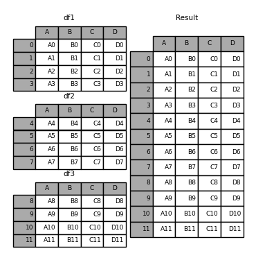

```python
pd.concat([df1,df2],axis = 1)  # here axis=1 which means along columns
```

|  | A | B | C | D | A | B | C | D |
| --- | --- | --- | --- | --- | --- | --- | --- | --- |
| 0 | A0 | B0 | C0 | D0 | NaN | NaN | NaN | NaN |
| 1 | A1 | B1 | C1 | D1 | NaN | NaN | NaN | NaN |
| 2 | A2 | B2 | C2 | D2 | NaN | NaN | NaN | NaN |
| 3 | A3 | B3 | C3 | D3 | NaN | NaN | NaN | NaN |
| 4 | NaN | NaN | NaN | NaN | A4 | B4 | C4 | D4 |
| 5 | NaN | NaN | NaN | NaN | A5 | B5 | C5 | D5 |
| 6 | NaN | NaN | NaN | NaN | A6 | B6 | C6 | D6 |
| 7 | NaN | NaN | NaN | NaN | A7 | B7 | C7 | D7 |

```python
pd.concat([df1,df2, df3],axis = 1)  # here axis=1 which means along columns
```

|  | A | B | C | D | A | B | C | D | A | B | C | D |
| --- | --- | --- | --- | --- | --- | --- | --- | --- | --- | --- | --- | --- |
| 0 | A0 | B0 | C0 | D0 | NaN | NaN | NaN | NaN | NaN | NaN | NaN | NaN |
| 1 | A1 | B1 | C1 | D1 | NaN | NaN | NaN | NaN | NaN | NaN | NaN | NaN |
| 2 | A2 | B2 | C2 | D2 | NaN | NaN | NaN | NaN | NaN | NaN | NaN | NaN |
| 3 | A3 | B3 | C3 | D3 | NaN | NaN | NaN | NaN | NaN | NaN | NaN | NaN |
| 4 | NaN | NaN | NaN | NaN | A4 | B4 | C4 | D4 | NaN | NaN | NaN | NaN |
| 5 | NaN | NaN | NaN | NaN | A5 | B5 | C5 | D5 | NaN | NaN | NaN | NaN |
| 6 | NaN | NaN | NaN | NaN | A6 | B6 | C6 | D6 | NaN | NaN | NaN | NaN |
| 7 | NaN | NaN | NaN | NaN | A7 | B7 | C7 | D7 | NaN | NaN | NaN | NaN |
| 8 | NaN | NaN | NaN | NaN | NaN | NaN | NaN | NaN | A8 | B8 | C8 | D8 |
| 9 | NaN | NaN | NaN | NaN | NaN | NaN | NaN | NaN | A9 | B9 | C9 | D9 |
| 10 | NaN | NaN | NaN | NaN | NaN | NaN | NaN | NaN | A10 | B10 | C10 | D10 |
| 11 | NaN | NaN | NaN | NaN | NaN | NaN | NaN | NaN | A11 | B11 | C11 | D11 |

```python
#creating df2 but with same index as in df1

df2_ = pd.DataFrame({'A': ['A4', 'A5', 'A6', 'A7'],
                    'B': ['B4', 'B5', 'B6', 'B7'],
                    'C': ['C4', 'C5', 'C6', 'C7'],
                    'D': ['D4', 'D5', 'D6', 'D7']},
                    index=[0, 1, 2, 3])
```

```python
pd.concat([df1,df2_])# by default axis=0 which means along rows
```

|  | A | B | C | D |
| --- | --- | --- | --- | --- |
| 0 | A0 | B0 | C0 | D0 |
| 1 | A1 | B1 | C1 | D1 |
| 2 | A2 | B2 | C2 | D2 |
| 3 | A3 | B3 | C3 | D3 |
| 0 | A4 | B4 | C4 | D4 |
| 1 | A5 | B5 | C5 | D5 |
| 2 | A6 | B6 | C6 | D6 |
| 3 | A7 | B7 | C7 | D7 |

Notice the repeated indices in the result. While this is valid within DataFrame s, the outcome is often undesirable.

If the index itself does not matter, and you would prefer them to be simply ignored, then you can specify this option using the `ignore_index`

```python
pd.concat([df1, df2_], ignore_index=True)
```

|  | A | B | C | D |
| --- | --- | --- | --- | --- |
| 0 | A0 | B0 | C0 | D0 |
| 1 | A1 | B1 | C1 | D1 |
| 2 | A2 | B2 | C2 | D2 |
| 3 | A3 | B3 | C3 | D3 |
| 4 | A4 | B4 | C4 | D4 |
| 5 | A5 | B5 | C5 | D5 |
| 6 | A6 | B6 | C6 | D6 |
| 7 | A7 | B7 | C7 | D7 |

```python
pd.concat([df1,df2_],axis = 1)  # axis=1 which means along columns

# observe the smartness of pandas here:
```

|  | A | B | C | D | A | B | C | D |
| --- | --- | --- | --- | --- | --- | --- | --- | --- |
| 0 | A0 | B0 | C0 | D0 | A4 | B4 | C4 | D4 |
| 1 | A1 | B1 | C1 | D1 | A5 | B5 | C5 | D5 |
| 2 | A2 | B2 | C2 | D2 | A6 | B6 | C6 | D6 |
| 3 | A3 | B3 | C3 | D3 | A7 | B7 | C7 | D7 |

```python
#creating a data frame with some common row and column names

df4 = pd.DataFrame({
                    'B': ['B4', 'B5', 'B6', 'B7'],
                    'D': ['D4', 'D5', 'D6', 'D7'],
                    "F": ["F2", "F3", "F6", "F7"]},
                    index=[2, 3, 6, 7])
df4
```

|  | B | D | F |
| --- | --- | --- | --- |
| 2 | B4 | D4 | F2 |
| 3 | B5 | D5 | F3 |
| 6 | B6 | D6 | F6 |
| 7 | B7 | D7 | F7 |

```python
pd.concat([df1, df4], axis=1)
```

|  | A | B | C | D | B | D | F |
| --- | --- | --- | --- | --- | --- | --- | --- |
| 0 | A0 | B0 | C0 | D0 | NaN | NaN | NaN |
| 1 | A1 | B1 | C1 | D1 | NaN | NaN | NaN |
| 2 | A2 | B2 | C2 | D2 | B4 | D4 | F2 |
| 3 | A3 | B3 | C3 | D3 | B5 | D5 | F3 |
| 6 | NaN | NaN | NaN | NaN | B6 | D6 | F6 |
| 7 | NaN | NaN | NaN | NaN | B7 | D7 | F7 |

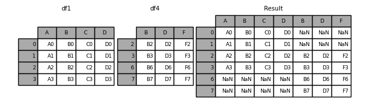

Here is the same thing with `join='inner'`:

```python
pd.concat([df1, df4], axis=1, join = "inner")
```

|  | A | B | C | D | B | D | F |
| --- | --- | --- | --- | --- | --- | --- | --- |
| 2 | A2 | B2 | C2 | D2 | B4 | D4 | F2 |
| 3 | A3 | B3 | C3 | D3 | B5 | D5 | F3 |

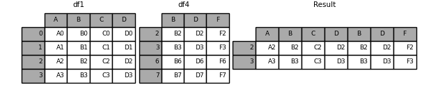

So for `.concat()` with `axis=1`:

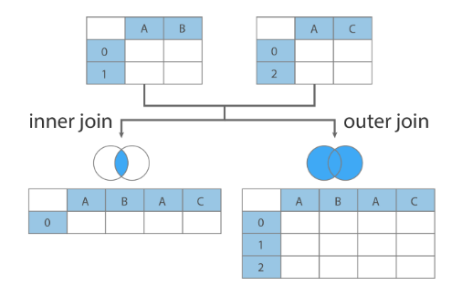

If `.concat()` with `axis=0`:

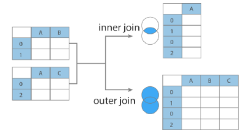

Keep in mind that unlike the `append()` and `extend()` methods of Python lists, the `append()` method in Pandas does not modify the original object instead, it creates a new object with the combined data. It also is not a very efficient method, because it involves creation of a new index and data buffer. Thus, if you plan to do multiple append operations, it is generally better to build a list of DataFrame s and pass them all at once to the `concat()` function.

## Joining

Joining is a convenient method for combining the columns of two potentially differently-indexed DataFrames into a single result DataFrame.

Among the three DataFrame operations, join allows the lowest level of control. It will combine all the columns from the two tables. The way that rows from the two tables are combined is defined by `how`.

```python
df_left = pd.DataFrame({'A': ['A0', 'A1', 'A2'],
                     'B': ['B0', 'B1', 'B2']},
                      index=['K0', 'K1', 'K2'])

df_right = pd.DataFrame({'C': ['C0', 'C2', 'C3'],
                    'D': ['D0', 'D2', 'D3']},
                      index=['K0', 'K2', 'K3'])
```

```python
df_left.join(df_right)
```

|  | A | B | C | D |
| --- | --- | --- | --- | --- |
| K0 | A0 | B0 | C0 | D0 |
| K1 | A1 | B1 | NaN | NaN |
| K2 | A2 | B2 | C2 | D2 |

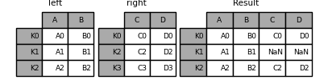

```python
df_left.join(df_right, how='outer')
```

|  | A | B | C | D |
| --- | --- | --- | --- | --- |
| K0 | A0 | B0 | C0 | D0 |
| K1 | A1 | B1 | NaN | NaN |
| K2 | A2 | B2 | C2 | D2 |
| K3 | NaN | NaN | C3 | D3 |

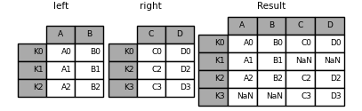

```python
df_left.join(df_right, how='inner')
```

|  | A | B | C | D |
| --- | --- | --- | --- | --- |
| K0 | A0 | B0 | C0 | D0 |
| K2 | A2 | B2 | C2 | D2 |

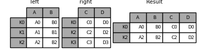

If their are common columns, they are renamed with the defined `lsuffix` and `rsuffix`.

```python
df_new = pd.DataFrame({'A': ['A00', 'A01', 'A02'],
                       'E': ['E00', 'E01', 'E02']},
                      index=['K0', 'K1', 'K2'])

df_new
```

|  | A | E |
| --- | --- | --- |
| K0 | A00 | E00 |
| K1 | A01 | E01 |
| K2 | A02 | E02 |

```python
df_left.join(df_new, rsuffix = '_new')
```

|  | A | B | A_new | E |
| --- | --- | --- | --- | --- |
| K0 | A0 | B0 | A00 | E00 |
| K1 | A1 | B1 | A01 | E01 |
| K2 | A2 | B2 | A02 | E02 |

```python
df_left.join(df_new, lsuffix = '_old')
```

|  | A_old | B | A | E |
| --- | --- | --- | --- | --- |
| K0 | A0 | B0 | A00 | E00 |
| K1 | A1 | B1 | A01 | E01 |
| K2 | A2 | B2 | A02 | E02 |

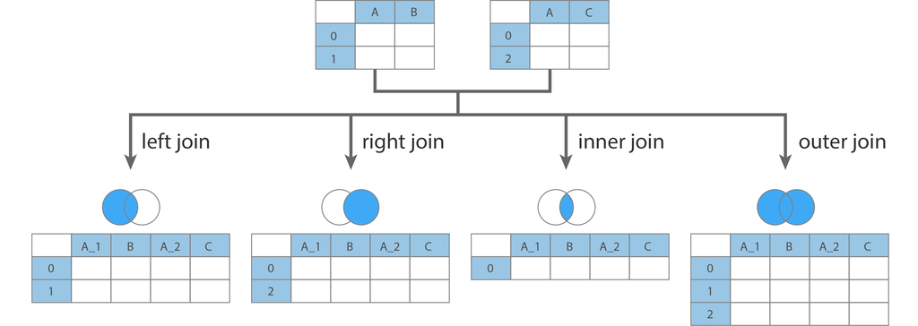

## Merging

Pandas has full-featured, high performance in-memory join operations idiomatically very similar to relational databases like SQL. Pandas provides a single function, `merge()`, as the entry point for all standard database join operations between DataFrame objects

Similar to join, merge also combines all the columns from the two tables. However, merge provides three ways of flexible control over row-wise alignment.

- The first way is to use `on = COLUMN NAME`, here the given column must be the common column in both tables.
- The second way is to use `left_on = COLUMN NAME` and `right_on = COLUMN NAME` , and it allows to align the two tables using two different columns.
- The third way is to use `left_index = True` and `right_index = True`, and the two tables are aligned based on their index.

Some of the useful arguments of a `pd.merge()` function:

- `left`: A DataFrame
- `right`: Another DataFrame
- `on`: Column or index level names to join on. Must be found in both the left and right DataFrame.
- `how`: One of `'left'`, `'right'`, `'outer'`, `'inner'`. Defaults to inner. See below for more detailed description of each method.
- `left_on`: Column or index level names to join on in the left DataFrame.
- `right_on`: Column or index level names to join on in the right DataFrame.
- `left_index`: Use the index from the left DataFrame as the join key.
- `right_index`: Use the index from the right DataFrame as the join key.
- `suffixes` : default is (“_x”, “_y”)

#### Example DataFrames

```python
df_left = pd.DataFrame({'key': ['K0', 'K1', 'K2', 'K3'],
                     'A': ['A0', 'A1', 'A2', 'A3'],
                     'B': ['B0', 'B1', 'B2', 'B3']})

df_right = pd.DataFrame({'key': ['K2', 'K3', 'K4', 'K5'],
                      'C': ['C0', 'C1', 'C2', 'C3'],
                      'D': ['D0', 'D1', 'D2', 'D3']})
```

```python
df_left
```

|  | key | A | B |
| --- | --- | --- | --- |
| 0 | K0 | A0 | B0 |
| 1 | K1 | A1 | B1 |
| 2 | K2 | A2 | B2 |
| 3 | K3 | A3 | B3 |

```python
df_right
```

|  | key | C | D |
| --- | --- | --- | --- |
| 0 | K2 | C0 | D0 |
| 1 | K3 | C1 | D1 |
| 2 | K4 | C2 | D2 |
| 3 | K5 | C3 | D3 |

```python
pd.merge(df_left,df_right, on = 'key')  #default how = 'inner'
```

|  | key | A | B | C | D |
| --- | --- | --- | --- | --- | --- |
| 0 | K2 | A2 | B2 | C0 | D0 |
| 1 | K3 | A3 | B3 | C1 | D1 |

```python
pd.merge(df_left,df_right,how = 'inner',on='key')
```

|  | key | A | B | C | D |
| --- | --- | --- | --- | --- | --- |
| 0 | K2 | A2 | B2 | C0 | D0 |
| 1 | K3 | A3 | B3 | C1 | D1 |

```python
pd.merge(df_left,df_right,how = 'outer',on='key')
```

|  | key | A | B | C | D |
| --- | --- | --- | --- | --- | --- |
| 0 | K0 | A0 | B0 | NaN | NaN |
| 1 | K1 | A1 | B1 | NaN | NaN |
| 2 | K2 | A2 | B2 | C0 | D0 |
| 3 | K3 | A3 | B3 | C1 | D1 |
| 4 | K4 | NaN | NaN | C2 | D2 |
| 5 | K5 | NaN | NaN | C3 | D3 |

```python
pd.merge(df_left,df_right,how = 'left',on='key')
```

|  | key | A | B | C | D |
| --- | --- | --- | --- | --- | --- |
| 0 | K0 | A0 | B0 | NaN | NaN |
| 1 | K1 | A1 | B1 | NaN | NaN |
| 2 | K2 | A2 | B2 | C0 | D0 |
| 3 | K3 | A3 | B3 | C1 | D1 |

```python
pd.merge(df_left,df_right,how = 'right',on='key')
```

|  | key | A | B | C | D |
| --- | --- | --- | --- | --- | --- |
| 0 | K2 | A2 | B2 | C0 | D0 |
| 1 | K3 | A3 | B3 | C1 | D1 |
| 2 | K4 | NaN | NaN | C2 | D2 |
| 3 | K5 | NaN | NaN | C3 | D3 |

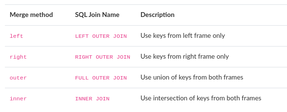

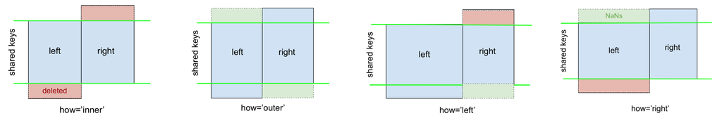

### Advanced Example:

```python
df1 = pd.DataFrame({'employee': ['Bob', 'Jake', 'Lisa', 'Sue'],
                    'group': ['Accounting', 'Engineering', 'Engineering', 'HR']})

df2 = pd.DataFrame({'employee': ['Lisa', 'Bob', 'Jake', 'Sue'],
                    'hire_date': [2004, 2008, 2012, 2014]})
```

```python
df1
```

|  | employee | group |
| --- | --- | --- |
| 0 | Bob | Accounting |
| 1 | Jake | Engineering |
| 2 | Lisa | Engineering |
| 3 | Sue | HR |

```python
df2
```

|  | employee | hire_date |
| --- | --- | --- |
| 0 | Lisa | 2004 |
| 1 | Bob | 2008 |
| 2 | Jake | 2012 |
| 3 | Sue | 2014 |

```python
pd.concat([df1,df2])
```

|  | employee | group | hire_date |
| --- | --- | --- | --- |
| 0 | Bob | Accounting | NaN |
| 1 | Jake | Engineering | NaN |
| 2 | Lisa | Engineering | NaN |
| 3 | Sue | HR | NaN |
| 0 | Lisa | NaN | 2004.0 |
| 1 | Bob | NaN | 2008.0 |
| 2 | Jake | NaN | 2012.0 |
| 3 | Sue | NaN | 2014.0 |

```python
pd.merge(df1, df2)
```

|  | employee | group | hire_date |
| --- | --- | --- | --- |
| 0 | Bob | Accounting | 2008 |
| 1 | Jake | Engineering | 2012 |
| 2 | Lisa | Engineering | 2004 |
| 3 | Sue | HR | 2014 |

The `pd.merge()` function recognizes that each DataFrame has an `employee` column, and automatically joins using this column as a key. The result of the merge is a new DataFrame that combines the information from the two inputs.

Additionally, keep in mind that the merge in general discards the index, except in the special case of merges by index.

```python
df3 = pd.DataFrame({'name': ['Bob', 'Jake', 'Lisa', 'Sue'],
                    'salary': [70000, 80000, 120000, 90000]})

df3
```

|  | name | salary |
| --- | --- | --- |
| 0 | Bob | 70000 |
| 1 | Jake | 80000 |
| 2 | Lisa | 120000 |
| 3 | Sue | 90000 |

```python
pd.merge(df1, df3, left_on="employee", right_on="name")
```

|  | employee | group | name | salary |
| --- | --- | --- | --- | --- |
| 0 | Bob | Accounting | Bob | 70000 |
| 1 | Jake | Engineering | Jake | 80000 |
| 2 | Lisa | Engineering | Lisa | 120000 |
| 3 | Sue | HR | Sue | 90000 |

The result has a redundant column that we can drop if desired—for example, by using the `drop()` method of DataFrames

```python
pd.merge(df1, df3, left_on="employee", right_on="name").drop('name', axis=1)
```

|  | employee | group | salary |
| --- | --- | --- | --- |
| 0 | Bob | Accounting | 70000 |
| 1 | Jake | Engineering | 80000 |
| 2 | Lisa | Engineering | 120000 |
| 3 | Sue | HR | 90000 |

Sometimes, rather than merging on a column, you would instead like to merge on an index.

```python
df1a = df1.set_index('employee')
df1a
```

| employee | group |
| --- | --- |
| Bob | Accounting |
| Jake | Engineering |
| Lisa | Engineering |
| Sue | HR |

```python
df2a = df2.set_index('employee')
df2a
```

| employee | hire_date |
| --- | --- |
| Lisa | 2004 |
| Bob | 2008 |
| Jake | 2012 |
| Sue | 2014 |

The index can be used as the key for merging by specifying the `left_index` and/or `right_index` flags in `pd.merge()`

```python
pd.merge(df1a, df2a, left_index=True, right_index=True)
```

| employee | group | hire_date |
| --- | --- | --- |
| Bob | Accounting | 2008 |
| Jake | Engineering | 2012 |
| Lisa | Engineering | 2004 |
| Sue | HR | 2014 |

Sometimes, you may end up in a case where your two input DataFrames having conflicting column names.

```python
df4 = pd.DataFrame({'name': ['Bob', 'Jake', 'Lisa', 'Sue'],'rank': [1, 2, 3, 4]})
df5 = pd.DataFrame({'name': ['Bob', 'Jake', 'Lisa', 'Sue'],'rank': [3, 1, 4, 2]})
```

```python
df4
```

|  | name | rank |
| --- | --- | --- |
| 0 | Bob | 1 |
| 1 | Jake | 2 |
| 2 | Lisa | 3 |
| 3 | Sue | 4 |

```python
df5
```

|  | name | rank |
| --- | --- | --- |
| 0 | Bob | 3 |
| 1 | Jake | 1 |
| 2 | Lisa | 4 |
| 3 | Sue | 2 |

```python
pd.merge(df4, df5, on="name")
```

|  | name | rank_x | rank_y |
| --- | --- | --- | --- |
| 0 | Bob | 1 | 3 |
| 1 | Jake | 2 | 1 |
| 2 | Lisa | 3 | 4 |
| 3 | Sue | 4 | 2 |

```python
pd.merge(df4, df5, on="name", suffixes=["_exam1", "_exam2"])
```

|  | name | rank_exam1 | rank_exam2 |
| --- | --- | --- | --- |
| 0 | Bob | 1 | 3 |
| 1 | Jake | 2 | 1 |
| 2 | Lisa | 3 | 4 |
| 3 | Sue | 4 | 2 |

### Summary

For `pandas.DataFrame`, both `join` and `merge` operates on columns and rename the common columns using the given suffix. In terms of row-wise alignment, `merge` provides more flexible control.

Different from `join` and `merge`, `concat` can operate on columns or rows, depending on the given axis, and no renaming is performed.